# Comparing Random Forest Approaches to Class-Imbalanced Payment Fraud Detection

Nicholas Pargoff and Andrew Mattson (Advisor: Dr. Cohen)

2026-11-27

## Introduction

- Payment fraud is increasing with growing e-commerce and new payment methods.
- FedNow (July 2023): offers financial institutions to send and receive instant payments any time and every day.
- As realtime payments increase, fraud models must flag transactions as they happen.

## Literature Review

- Accuracy is not used as a measurement metric.
- Studies use precision, recall, F1, and AUC-PR instead.
- RF has been proven effective for credit card fraud.
- Pairing RF and SMOTE is common but not always the best option.
- Studies use different datasets and metrics resulting in studies that are hard to compare.

## Methodology: Random Forest

- Each tree trains on a bootstrap sample of the training data.
  $$D_b \sim \text{Bootstrap}(D), \quad b = 1, \dots, B$$
- A random subset of features used for each split.
- Assumptions: Observations are independent, but same users appear in training and testing data, and the folds ignore time order.

## Methodology: Class Imbalance Treatments

- Baseline - no adjustment for imbalance.
- SMOTE-NC - creates synthetic fraud cases from a fraud case and its nearest fraud neighbors.
- Balanced RF - each tree trains on a balanced sample by undersampling legitimate transactions.
- Class weighting - fraud cases get more weight when choosing splits.

## Methodology: Procedure

- 5-fold cross validation for 10 repeats (50 test folds).
- All four models used the same folds and 500 trees (randomForest package).
- Everything was run with and without the risk score.

| Part | Share of all data | Used for |
| --- | --- | --- |
| Model fitting | 60% (75% of the training set) | Fitting the model; SMOTE-NC applied here only |
| Threshold selection | 20% (25% of the training set) | Choosing the threshold that maximizes F1 |
| Test fold | 20% | Scoring the model once |

## Methodology: Metrics

- All metrics are for the fraud class
- AUC-PR - area under the precision-recall curve for all thresholds
- Random guessing gives AUC-PR of about 0.013

$$\text{Precision} = \frac{TP}{TP + FP}, \quad
\text{Recall} = \frac{TP}{TP + FN}, \quad
F_1 = \frac{2 \cdot \text{Precision} \cdot \text{Recall}}
{\text{Precision} + \text{Recall}}$$

## Data Exploration and Visualizations

- 10,000 synthetic transactions, August 2025 to August 2026 (Kaggle, greatcool 2026)
- 2,142 users, no missing values
- 126 fraud (1.26%)
- 6 predictors: account type, category, payment method, device type, amount, risk score

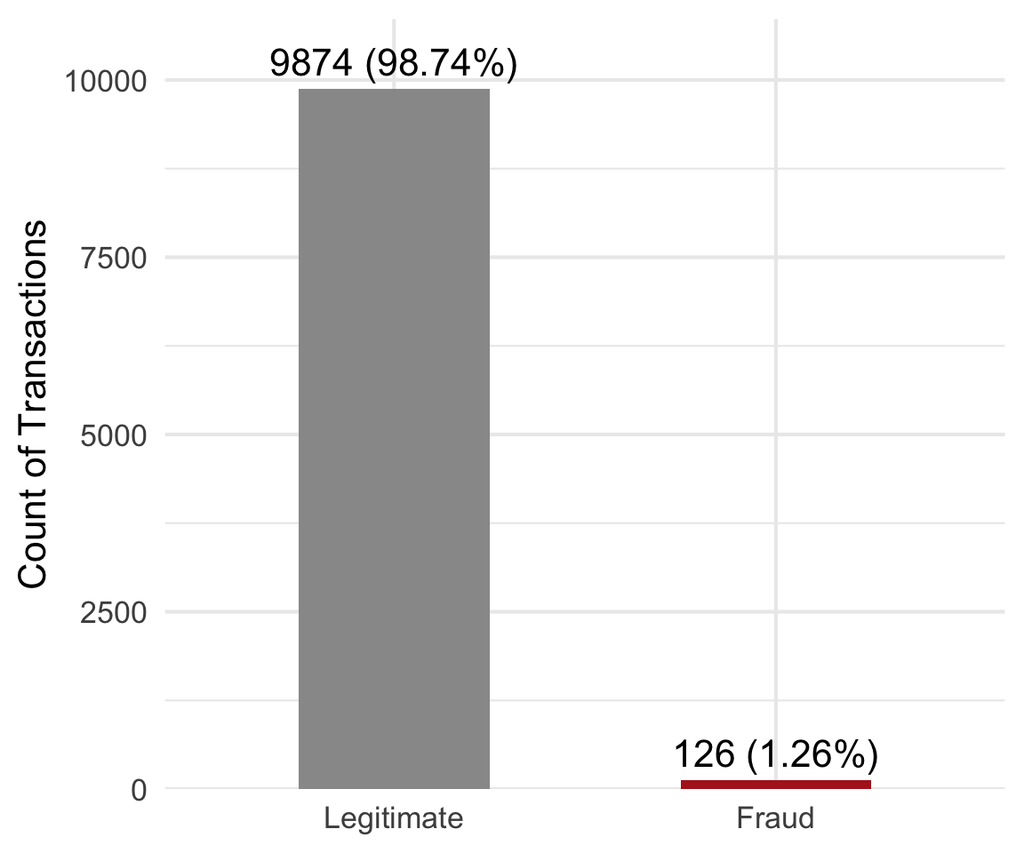

## Data Exploration and Visualization (continued)

- Risk score was the only variable that differed between fraud and legitimate transactions (p < 0.001)
- Median risk score: 33 for fraud, 27 for legitimate
- Its calculation is undocumented, so it may cause data leakage

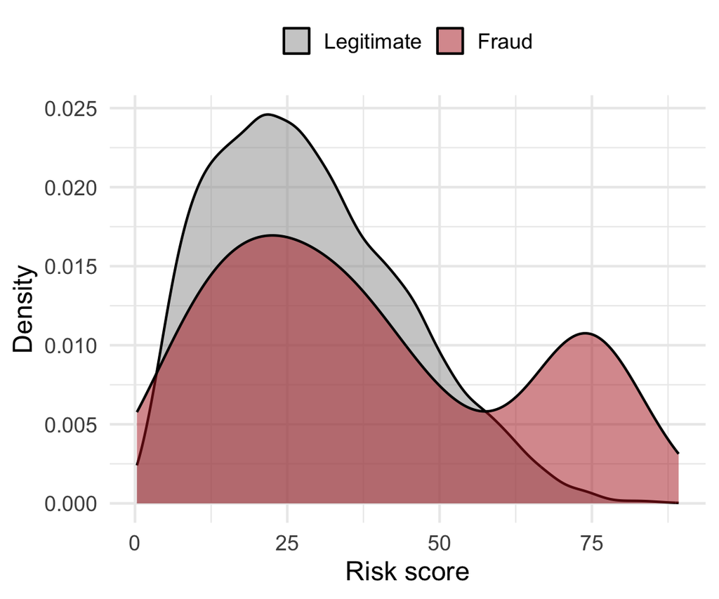

## Results: Risk Score Included

| Method | AUC-PR | Precision | Recall | F1 |
| --- | --- | --- | --- | --- |
| Balanced RF | 0.089 | 0.235 | 0.189 | 0.203 |
| Baseline RF | 0.084 | 0.204 | 0.180 | 0.185 |
| SMOTE-NC | 0.020 | 0.025 | 0.111 | 0.028 |
| Class weighting | 0.033 | 0.053 | 0.064 | 0.044 |

- Balanced RF (0.089) and Baseline (0.084) performed about the same
- SMOTE-NC (0.020) was barely above random guessing (0.013)

## Results: False Alarms

| Method | Caught | Missed | False alarms |
| --- | --- | --- | --- |
| Balanced RF | 24 | 102 | 77 |
| Baseline RF | 23 | 103 | 88 |
| SMOTE-NC | 14 | 112 | 678 |
| Class weighting | 8 | 118 | 212 |

- SMOTE-NC caught 14 fraud cases with 678 false alarms
- Baseline caught 23 with 88 false alarms, about 8 times fewer

## Results: Risk Score Removed

| Method | AUC-PR | Precision | Recall | F1 |
| --- | --- | --- | --- | --- |
| Balanced RF | 0.014 | 0.009 | 0.189 | 0.015 |
| Baseline RF | 0.015 | 0.017 | 0.205 | 0.019 |
| SMOTE-NC | 0.013 | 0.014 | 0.215 | 0.023 |
| Class weighting | 0.018 | 0.015 | 0.138 | 0.018 |

- All four models’ AUC-PR and F1 dropped
- AUC-PR of 0.013 to 0.018 is about the same as random guessing (0.013)
- Recall increased because the models flagged more legitimate transactions
- The models relied on the risk score

## Conclusion

- Balanced RF and Baseline had the highest AUC-PR, and no treatment clearly beat Baseline
- SMOTE-NC produced about 8 times as many false alarms as Baseline
- The risk score was the main signal in this data.
- **Limitations:** undocumented risk score, about 25 fraud cases per test fold, synthetic data